# H06 Stage 2 amendment pilot: revised V0 scaffold models

Feasibility assessment only — no H06 result is accepted

Published

August 6, 2026

# Assessment at a glance

**ImportantPilot conclusion**

The **V0 fixed-effects scaffold can be retained**, with exercise collapsed to sedentary or active. The **V0 participant-only random structure cannot be retained as the inferential basis**: it is nonsingular, but leaves substantial within-day dependence and fails the simulated distributional checks at both placements.

Of the six piloted dependence/error strategies, only the **participant-cluster robust marginal log-mean model** remains structurally estimable without requiring a full Tweedie outcome distribution. It is the recommended candidate for a production amendment, preferably with HC3 as the leverage-sensitive covariance specification. This is not yet an accepted H06 model or result. The candidate remains sensitive to individual participants, especially for the chest activity estimate, and must pass the complete predeclared Stage 2 sensitivity and reporting contract before any H06 claim or Stage 3 transition.

The pilot preserves the deliberate hourly outcome and approved average-effect question. It does not reopen the registered daily-metric alternative, add a local-clock effect, add temperature, change the immutable source pin, or alter shared preparation. The local-clock profile below is a residual calibration diagnostic only; the separate exploratory GAM/GAMM remains the analysis of time of day.

# Fixed-effects scaffold and exact samples

Every candidate uses this exact hierarchy-preserving fixed scaffold:

**Show audit code**

```r
response_value ~
  site * work_free_day +
  site * activity_status +
  site * previous_sleep_duration_centered_h
```

`activity_status` has exactly two levels: sedentary (no reported exercise) and active (light, moderate, or vigorous exercise). Submitted site ordering is retained, with sum contrasts so each displayed main coefficient is the equal-site average association represented by that fitted model. The mixed models estimate conditional associations, whereas the cluster-robust model estimates a population-average mean association; their numerical estimates are therefore a model-dependence diagnostic rather than interchangeable versions of one inferential result.

Exact common pilot frames

The same repaired three-predictor frame is used by all six candidates within each placement.

| Placement | Hours | Participant-days | Participants | Sites | Fixed design | Frame SHA-256 |
| --- | --- | --- | --- | --- | --- | --- |
| Near-eye | 16596 | 715 | 137 | 9 | 36/36 | ec9049b3a0c0f3b237c66a471ffdbaa1a86afe8e8e4983f6fd5deea97472950e |
| Chest | 18352 | 789 | 149 | 8 | 32/32 | c0ca0c3ec0c2257756fea345ed00de0d47a6130db210732258166a0a922f51e9 |

Near-eye contains 16,596 supported one-hour observations from 715 participant-days, 137 participants, and nine sites. Chest contains 18,352 hours from 789 participant-days, 149 participants, and eight sites. Both fixed designs are full rank. These are the approved primary-dataset frames; no new filter was introduced for the pilot.

# Six piloted strategies

V0-scaffold candidate registry

All formulas were evaluated under R 4.6.1. Every fit is a feasibility pilot, not accepted inference.

| Candidate | Engine | Outcome/mean specification | Dependence strategy | Formula |
| --- | --- | --- | --- | --- |
| V0 participant intercept | glmmTMB | Tweedie with log link | Participant random intercept only | `response_value ~ site * work_free_day + site * activity_status + site * previous_sleep_duration_centered_h + (1 \| participant_key)` |
| Participant + participant-day intercepts | glmmTMB | Tweedie with log link | Participant and participant-day random intercepts; no serial term | `response_value ~ site * work_free_day + site * activity_status + site * previous_sleep_duration_centered_h + (1 \| participant_key) + (1 \| participant_day_key)` |
| Participant + latent AR(1) | glmmTMB | Tweedie with log link | Participant random intercept plus gap-bounded latent AR(1); no day intercept | `response_value ~ site * work_free_day + site * activity_status + site * previous_sleep_duration_centered_h + (1 \| participant_key) + ar1(hour_index_factor + 0 \| hour_sequence_id)` |
| Participant + day + latent AR(1) | glmmTMB | Tweedie with log link | Participant and day intercepts plus gap-bounded latent AR(1) | `response_value ~ site * work_free_day + site * activity_status + site * previous_sleep_duration_centered_h + (1 \| participant_key) + (1 \| participant_day_key) + ar1(hour_index_factor + 0 \| hour_se… |
| Participant + day + working AR(1) | mgcv::bam | Tweedie with log link | Penalized participant and day random effects plus gap-bounded working-residual AR(1) | `response_value ~ site * work_free_day + site * activity_status + site * previous_sleep_duration_centered_h + s(participant_key, bs = "re") + s(participant_day_key, bs = "re")` |
| Participant-cluster robust marginal | stats::glm + sandwich::vcovCL | Quasi-Poisson mean-variance with log link | Working independence with participant-cluster CR1 covariance | `response_value ~ site * work_free_day + site * activity_status + site * previous_sleep_duration_centered_h` |

The working-AR candidate uses `mgcv::bam(method = "fREML", discrete = TRUE)` for both the initial and AR-aware fits. No model, prediction, interval, simulation, or downstream computation in this pilot uses or requires `discrete = FALSE`.

# Structural, temporal, and distributional screens

Automated feasibility screens

For BAM, the temporal screen uses AR-standardized residuals. For the marginal robust model, residual correlation is allowed and is handled by participant-cluster covariance.

| Placement | Candidate | Structural | Lag-1 used for screen | Temporal | Distribution |
| --- | --- | --- | --- | --- | --- |
| Chest | V0 participant intercept | Pass | 0.299 | Fail | Fail |
| Chest | Participant + participant-day intercepts | Pass | 0.286 | Fail | Fail |
| Chest | Participant + latent AR(1) | Fail: boundary/singular | 0.001 | Pass | Fail |
| Chest | Participant + day + latent AR(1) | Fail: boundary/singular | 0.001 | Pass | Fail |
| Chest | Participant + day + working AR(1) | Fail: boundary/singular | 0.083 | Pass | Fail |
| Chest | Participant-cluster robust marginal | Estimable marginal candidate | 0.404 | Not a model-validity test | Not specified by design |
| Near-eye | V0 participant intercept | Pass | 0.356 | Fail | Fail |
| Near-eye | Participant + participant-day intercepts | Pass | 0.341 | Fail | Fail |
| Near-eye | Participant + latent AR(1) | Fail: boundary/singular | 0.057 | Pass | Fail |
| Near-eye | Participant + day + latent AR(1) | Fail: boundary/singular | 0.057 | Pass | Fail |
| Near-eye | Participant + day + working AR(1) | Fail: boundary/singular | 0.105 | Fail | Fail |
| Near-eye | Participant-cluster robust marginal | Estimable marginal candidate | 0.460 | Not a model-validity test | Not specified by design |

The two nonsingular Tweedie models—the V0 participant intercept and the added participant-day intercept—still have lag-1 residual correlations of 0.286–0.356 and fail every applicable 100-simulation distribution screen. Adding latent AR(1) removes most residual lag but collapses participant and, where present, participant-day variance to the boundary. The discrete BAM working-AR fit likewise collapses both random-effect penalties and fails its simulated distribution checks; near-eye standardized lag-1 is 0.105, just outside the declared 0.10 screen.

The GAMM-specific re-audit strengthens that conclusion. The pooled lag used by the original automated screen hides a broad distribution across short within-day series. The table therefore reports per-sequence medians and interquartile ranges, along with the fitted Tweedie and smooth-penalty parameters.

Stored BAM re-audit

No model was refitted and no simulation was added; all diagnostics come from the stored discrete BAM and its existing 100 simulations.

| Placement | Tweedie p | Dispersion phi | Working rho | Participant EDF | Participant-day EDF | Standardized lag-1, median (IQR) | Observed / simulated zeros | In-sample deviance explained |
| --- | --- | --- | --- | --- | --- | --- | --- | --- |
| Near-eye | 1.898 | 96.961 | 0.768 | 0.000 | 0.000 | 0.199 (-0.083 to 0.414) | 28.3% / 84.7% | 0.046 |
| Chest | 1.902 | 83.520 | 0.735 | 0.000 | 0.000 | 0.167 (-0.108 to 0.395) | 29.1% / 82.1% | 0.042 |

The estimated Tweedie powers are about 1.90 within the default 1.01–1.99 search interval, with dispersion about 84–97. The participant and participant-day smooth EDFs are below 0.001 at both placements: their penalized contributions are effectively absent even though a classical mixed-model singularity flag is not available for BAM. Median AR-standardized within-sequence lag remains 0.199 near-eye and 0.167 chest, with wide interquartile ranges. Thus the working AR term reduces pooled dependence but does not establish homogeneous residual independence.

For a non-Gaussian BAM, `rho` is a working-residual GEE approximation rather than a full joint or generative AR likelihood. The existing 100 custom simulations likewise test the marginal conditional Tweedie response distribution; they do not simulate a full AR process. That marginal test is already decisive: the model generates 84.7% zero near-eye hours and 82.1% zero chest hours, compared with 28.3% and 29.1% observed. Uniformity and zero-mass raw diagnostic *p* values are zero, and outlier diagnostics are also incompatible. Positive-tail calibration was not separately tested in the stored pilot, which is an additional missing adequacy check rather than a reason to rehabilitate the model. A compound-process Tweedie distribution is not made scientifically compelling merely by zeros and skew in an hourly zero-aware geometric-mean light metric.

Bounded simulation diagnostics for generative candidates

Exactly 100 conditional simulations per placement and candidate; displayed values are raw diagnostic p-values with no significance styling or H06 decision rule.

| Placement | Candidate | Simulations | Uniformity diagnostic p | Dispersion diagnostic p | Zero-mass diagnostic p | Outlier diagnostic p |
| --- | --- | --- | --- | --- | --- | --- |
| Chest | V0 participant intercept | 100 | <0.001 | <0.001 | <0.001 | <0.001 |
| Chest | Participant + participant-day intercepts | 100 | <0.001 | <0.001 | <0.001 | <0.001 |
| Chest | Participant + latent AR(1) | 100 | <0.001 | 0.620 | <0.001 | <0.001 |
| Chest | Participant + day + latent AR(1) | 100 | <0.001 | 0.880 | <0.001 | <0.001 |
| Chest | Participant + day + working AR(1) | 100 | <0.001 | 0.040 | <0.001 | <0.001 |
| Near-eye | V0 participant intercept | 100 | <0.001 | <0.001 | <0.001 | <0.001 |
| Near-eye | Participant + participant-day intercepts | 100 | <0.001 | <0.001 | <0.001 | 0.253 |
| Near-eye | Participant + latent AR(1) | 100 | <0.001 | 0.820 | <0.001 | <0.001 |
| Near-eye | Participant + day + latent AR(1) | 100 | <0.001 | 0.880 | <0.001 | <0.001 |
| Near-eye | Participant + day + working AR(1) | 100 | <0.001 | <0.001 | <0.001 | <0.001 |

The ten generative candidate-placement checks took 21.7 seconds at 100 simulations. A linear projection to 1,000 simulations is 217.3 seconds in total, with a maximum of 47.8 seconds for one fit. No production simulation or bootstrap was run because every generative candidate already fails clearly and no larger run was authorized.

# How the candidate estimates move

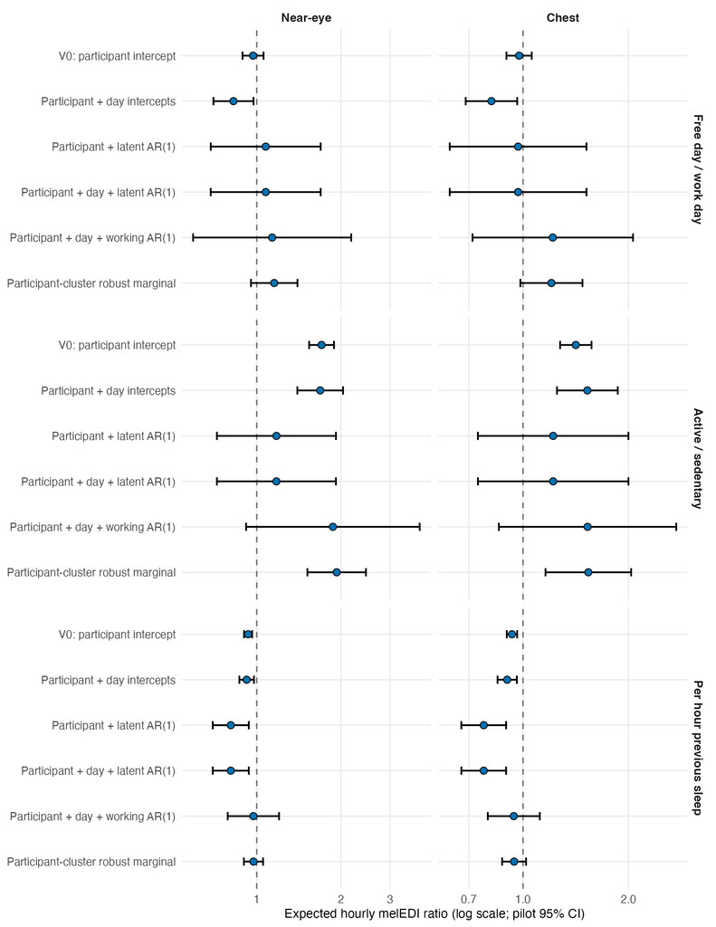

Equal-site average effect ratios and pilot 95% intervals under six V0-scaffold dependence/error strategies. These intervals are feasibility output, not accepted H06 inference.

Figure source: `artifacts/11_source_data/H06/H06_v0_scaffold_pilot_effects_figure.csv`.

The spread is scientifically consequential. Near-eye previous-sleep ratios range from 0.808 under the singular latent-AR fit to 0.973 under the marginal robust fit; the analogous chest range is 0.772 to 0.943. Activity ranges from 1.18 to 1.93 near-eye and 1.22 to 1.54 chest. This is model dependence, not a menu from which to select a preferred finding.

The robust candidate’s covariance-only leverage sensitivity is:

Participant-cluster robust covariance sensitivity

HC3 increases protection against influential clusters. Intervals use t critical values with participant clusters minus one degree of freedom and are not accepted inference.

| Placement | Effect | Covariance | Ratio (pilot 95% CI) |
| --- | --- | --- | --- |
| Near-eye | Free day / work day | HC1 | 1.15 × (0.95 to 1.40) |
| Near-eye | Active / sedentary | HC1 | 1.93 × (1.52 to 2.46) |
| Near-eye | Per hour previous sleep | HC1 | 0.97 × (0.90 to 1.05) |
| Near-eye | Free day / work day | HC3 | 1.15 × (0.93 to 1.44) |
| Near-eye | Active / sedentary | HC3 | 1.93 × (1.42 to 2.63) |
| Near-eye | Per hour previous sleep | HC3 | 0.97 × (0.88 to 1.08) |
| Chest | Free day / work day | HC1 | 1.21 × (0.98 to 1.48) |
| Chest | Active / sedentary | HC1 | 1.54 × (1.16 to 2.04) |
| Chest | Per hour previous sleep | HC1 | 0.94 × (0.87 to 1.02) |
| Chest | Free day / work day | HC3 | 1.21 × (0.95 to 1.52) |
| Chest | Active / sedentary | HC3 | 1.54 × (1.08 to 2.18) |
| Chest | Per hour previous sleep | HC3 | 0.94 × (0.85 to 1.05) |

HC3 increases the largest target standard error by a factor of 1.33 near-eye and 1.31 at chest. The activity intervals remain above one in this pilot; the free-day and sleep intervals include one. No p-values or multiplicity decisions are made here.

# Stress test of the robust marginal candidate

The quasi-Poisson variance is deliberately only a working variance: deviance/residual-df is 744.9 near-eye and 834.5 chest. Model-based quasi-Poisson standard errors are therefore not used. The candidate relies on participant-cluster sandwich covariance and a log mean model, not a claim that melEDI is Poisson distributed.

Mean calibration by fitted-value decile is comparatively close but not exact: observed/fitted ratios range from 0.880 to 1.211 near-eye and 0.901 to 1.172 chest. The diagnostic local-clock ratios span roughly 0.001–3.017 near-eye and 0.002–2.970 chest, confirming strong time-of-day patterning intentionally left to the exploratory GAM/GAMM. This does not silently add a clock term or change the approved observed-supported-hour-weighted estimand.

Largest exact shift among five score-ranked participant deletions

This is a targeted influence screen, not an exclusion rule. All refits converged at full fixed-effect rank.

| Placement | Effect | Deleted participant | Full ratio | Deleted-participant ratio | Shift / full HC1 SE |
| --- | --- | --- | --- | --- | --- |
| Near-eye | Free day / work day | FUSPCEU::FUSPCEU_S004 | 1.15 | 1.08 | -0.69 |
| Near-eye | Active / sedentary | THUAS::THUAS_S011 | 1.93 | 2.10 | 0.68 |
| Near-eye | Per hour previous sleep | BAUA::BAUA_S012 | 0.97 | 0.94 | -0.77 |
| Chest | Free day / work day | FUSPCEU::FUSPCEU_S004 | 1.21 | 1.12 | -0.67 |
| Chest | Active / sedentary | THUAS::THUAS_S011 | 1.54 | 1.89 | 1.46 |
| Chest | Per hour previous sleep | BAUA::BAUA_S009 | 0.94 | 0.97 | 0.79 |

The largest targeted deletion is the chest activity coefficient after removing `THUAS_S011`: its shift is 1.46 full-model HC1 standard errors. Near-eye’s maximum is 0.77 standard errors. No participant is excluded; this finding is a reason to use an influence-sensitive covariance and to retain the full deterministic influence audit in production.

All nine near-eye and eight chest leave-one-site refits also converge at full reduced-frame rank. The maximum absolute log-coefficient changes are 0.097 near-eye and 0.145 chest. Those deletions are screening diagnostics only: removing a site changes the equal-site estimand to the average over the remaining sites, so they are not common-estimand sensitivity estimates.

# Reader-facing figure verification

REPORT-011 physical-size verification

PASS: no clipping, overlap, wrapping, or distortion; candidate labels, facet labels, axes, points, and 95% CI whiskers are legible; the two placement panels and three effect rows have balanced data regions.

| Figure | Native size | Intended width | Scale factor | Smallest nominal text | Effective text | Status |
| --- | --- | --- | --- | --- | --- | --- |
| H06_v0_scaffold_pilot_effects | 170 × 220 mm | 170 mm | 1.00 | 7.5 pt | 7.5 pt | PASS |

The figure was assessed at 170 mm on a 210 × 297 mm A4 portrait page with 20-mm side margins. The 170-mm native width gives a scale factor of 1.00 and the smallest essential text remains 7.5 pt. The archived physical-size page is `artifacts/12_manifests/H06/qa/H06_v0_scaffold_pilot_effects_A4_preview.pdf`.

# Recommendation and remaining gate

The pilot supports a narrow conclusion about **model development**, not H06:

1. **Do not use the V0 participant-only mixed model as the revised basis.** It is nonsingular but does not repair repeated participant-days, serial dependence, or the outcome distribution.
2. **Do not use either latent-AR Tweedie model or the BAM working-AR model.** Their dependence components are not jointly identifiable on these frames, and their generative diagnostics fail.
3. **Take the participant-cluster robust marginal log-mean model forward as the only viable candidate.** Preserve the exact V0 fixed-effects scaffold, binary activity, sum-coded site hierarchy, observed-supported-hour average, and no confirmatory clock effect. Use participant-cluster HC3 covariance as the leverage-sensitive primary candidate, with HC1 shown as a covariance sensitivity.
4. Before it can replace the failed Stage 2 model, run the already-required robust additive and site-heterogeneity tests with REPORT-008 p-values and the existing multiplicity families; exact near-eye/chest and paired/common samples; gap-timing-unaware sensitivity; full deterministic influence; calibration; and recreated reader outputs. Any heavy resampling remains separately gated at 50 or 100 pilot replicates.

The author decision is therefore whether to authorize that narrowly specified robust-marginal production amendment. Until then, this pilot remains feasibility evidence, the original Stage 2 adequacy failure remains in force, no H06 result or claim is accepted, and Stage 3 remains blocked.

# Reproducibility record

- R version: 4.6.1.
- Scientific pilot: `scripts/hypotheses/H06/pilot_h06_v0_scaffold_models.R`.
- Robust calibration/influence checks: `scripts/hypotheses/H06/assess_h06_v0_scaffold_robust_candidate.R`.
- Stored BAM GAMM re-audit: `scripts/hypotheses/H06/audit_h06_stored_bam_models.R`.
- Reader artifact builder: `scripts/hypotheses/H06/build_h06_v0_scaffold_pilot_reader_artifacts.R`.
- Fitted objects: `artifacts/07_models/H06/H06_v0_scaffold_pilot_models.rds`.
- Strengthened BAM diagnostics: `artifacts/08_diagnostics/H06/H06_v0_scaffold_pilot_bam_gamm_audit.csv` and the paired per-sequence lag CSV.
- Every output is labelled `feasibility_pilot_not_accepted_inference` or the corresponding pilot-diagnostic status.